# Hauspreis Vorhersage: Der Schlüssel zu fundierten Immobilienentscheidungen

**Ziel:** Entschlüsselung der entscheidenden Faktoren, die den Preis eines Hauses beeinflussen – wie Größe, Lage und Ausstattung.

In einer Welt, in der Immobilienpreise oft schwanken und schwer vorhersehbar sind, bietet dieses Projekt eine zuverlässige Lösung: Ein prädiktives Modell, das Hauspreise mit hoher Genauigkeit schätzt. Dabei werden Faktoren wie Fläche, Anzahl der Schlafzimmer, Ausstattung und andere relevante Immobilienmerkmale berücksichtigt, um präzise Preisprognosen zu ermöglichen.

Zusätzlich wird durch eine gründliche explorative Datenanalyse (EDA) aufgezeigt, welche Muster und Zusammenhänge den Preis beeinflussen. Diese wertvollen Erkenntnisse sind für Investoren, Käufer und Verkäufer von großer Bedeutung und helfen dabei, fundierte, datenbasierte Entscheidungen im Immobilienmarkt zu treffen.

```python
%matplotlib inline
import plotly.io as pio
pio.renderers.default = "notebook"

# Libraries
import pandas as pd
import numpy as np
import matplotlib.pyplot as plt
import plotly.express as px
import seaborn as sns
from sklearn.model_selection import train_test_split
from sklearn.linear_model import LinearRegression
from sklearn.tree import DecisionTreeRegressor
from sklearn.ensemble import RandomForestRegressor, GradientBoostingRegressor
from sklearn.metrics import mean_squared_error, r2_score
from sklearn.preprocessing import StandardScaler

# Ignore warnings for cleaner output
import warnings
warnings.filterwarnings("ignore")
```

# 1) Setup & Data Preparation

```python
df = pd.read_csv('Housing.csv')
df.head()
```

|  | price | area | bedrooms | bathrooms | stories | mainroad | guestroom | basement | hotwaterheating | airconditioning | parking | prefarea | furnishingstatus |
| --- | --- | --- | --- | --- | --- | --- | --- | --- | --- | --- | --- | --- | --- |
| 0 | 13300000 | 7420 | 4 | 2 | 3 | yes | no | no | no | yes | 2 | yes | furnished |
| 1 | 12250000 | 8960 | 4 | 4 | 4 | yes | no | no | no | yes | 3 | no | furnished |
| 2 | 12250000 | 9960 | 3 | 2 | 2 | yes | no | yes | no | no | 2 | yes | semi-furnished |
| 3 | 12215000 | 7500 | 4 | 2 | 2 | yes | no | yes | no | yes | 3 | yes | furnished |
| 4 | 11410000 | 7420 | 4 | 1 | 2 | yes | yes | yes | no | yes | 2 | no | furnished |

```python
# Display basic information about the dataset
print("Dataset Info:")
print(df.info())
```

```
Dataset Info:
<class 'pandas.core.frame.DataFrame'>
RangeIndex: 545 entries, 0 to 544
Data columns (total 13 columns):
 #   Column            Non-Null Count  Dtype
---  ------            --------------  -----
 0   price             545 non-null    int64
 1   area              545 non-null    int64
 2   bedrooms          545 non-null    int64
 3   bathrooms         545 non-null    int64
 4   stories           545 non-null    int64
 5   mainroad          545 non-null    object
 6   guestroom         545 non-null    object
 7   basement          545 non-null    object
 8   hotwaterheating   545 non-null    object
 9   airconditioning   545 non-null    object
 10  parking           545 non-null    int64
 11  prefarea          545 non-null    object
 12  furnishingstatus  545 non-null    object
dtypes: int64(6), object(7)
memory usage: 55.5+ KB
None
```

```python
# Summary statistics for numerical features
print("Summary Statistics:")
print(df.describe())
```

```
Summary Statistics:
              price          area    bedrooms   bathrooms     stories  \
count  5.450000e+02    545.000000  545.000000  545.000000  545.000000
mean   4.766729e+06   5150.541284    2.965138    1.286239    1.805505
std    1.870440e+06   2170.141023    0.738064    0.502470    0.867492
min    1.750000e+06   1650.000000    1.000000    1.000000    1.000000
25%    3.430000e+06   3600.000000    2.000000    1.000000    1.000000
50%    4.340000e+06   4600.000000    3.000000    1.000000    2.000000
75%    5.740000e+06   6360.000000    3.000000    2.000000    2.000000
max    1.330000e+07  16200.000000    6.000000    4.000000    4.000000

          parking
count  545.000000
mean     0.693578
std      0.861586
min      0.000000
25%      0.000000
50%      0.000000
75%      1.000000
max      3.000000
```

**Statistische Zusammenfassung**

Preisdurchschnitt: Der durchschnittliche Preis liegt bei etwa 4,77 Millionen, mit einer hohen Standardabweichung (1,87 Millionen), was auf eine große Preisspanne hinweist.

Fläche: Die durchschnittliche Fläche beträgt etwa 5150 Quadratfuß, was darauf hindeutet, dass die meisten Immobilien relativ geräumig sind.

Schlafzimmer und Badezimmer: Im Durchschnitt haben die Häuser etwa 3 Schlafzimmer und 1,3 Badezimmer, was typische Familienbedürfnisse widerspiegelt.

```python
# Check for missing values
print("Missing Values:")
print(df.isnull().sum())
```

```
Missing Values:
price               0
area                0
bedrooms            0
bathrooms           0
stories             0
mainroad            0
guestroom           0
basement            0
hotwaterheating     0
airconditioning     0
parking             0
prefarea            0
furnishingstatus    0
dtype: int64
```

# 2) Exploratory Data Analysis (EDA)

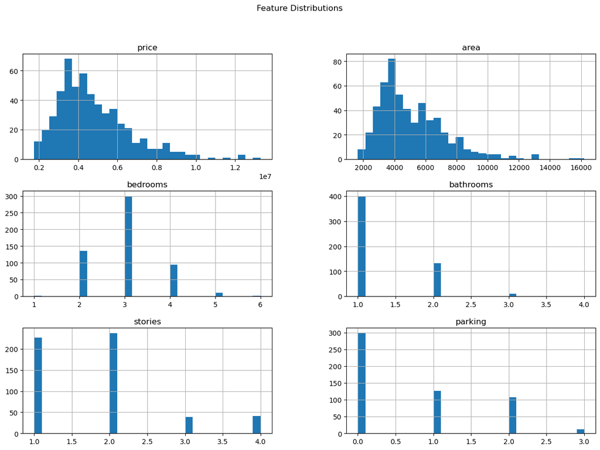

```python
# Visualize Feature Distributions
df.hist(bins=30, figsize=(15, 10))
plt.suptitle("Feature Distributions")
plt.show()
```

**Verteilung der Merkmale:** Die rechtsschiefe Verteilung der Preise und Flächen deutet darauf hin, dass die Mehrheit der Immobilien im unteren Preissegment liegt, während einige sehr teure Immobilien den Durchschnitt nach oben ziehen.

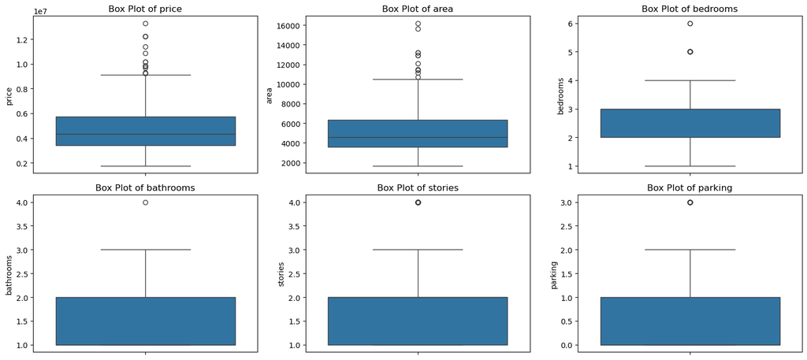

```python
# Box plots to detect outliers
plt.figure(figsize=(15, 10))
for i, column in enumerate(df.select_dtypes(include=['float64', 'int64']).columns):
    plt.subplot(3, 3, i + 1)
    sns.boxplot(data=df, y=column)
    plt.title(f"Box Plot of {column}")
plt.tight_layout()
plt.show()
```

**Outlier-Identifikation:** Die Boxplots zeigen, dass es einige Ausreißer im Preis gibt, die möglicherweise Luxusimmobilien darstellen. Diese sollten bei der Modellierung berücksichtigt werden, um Verzerrungen zu vermeiden.

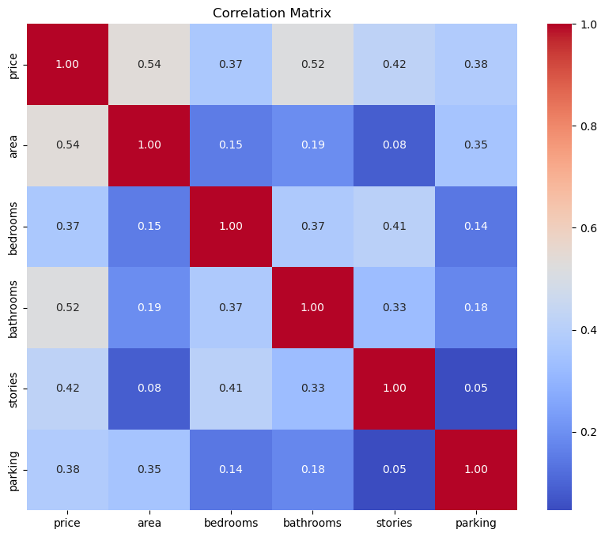

```python
# Correlation Matrix
correlation_matrix = df.corr(numeric_only=True) # Add numeric_only=True
plt.figure(figsize=(10, 8))
sns.heatmap(correlation_matrix, annot=True, cmap='coolwarm', fmt='.2f')
plt.title("Correlation Matrix")
plt.show()
```

**Schwache Korrelationen**: Merkmale wie die Anzahl der Etagen und Parkplätze haben eine schwächere Korrelation mit dem Preis, was darauf hindeutet, dass sie weniger Einfluss auf den Preis haben.

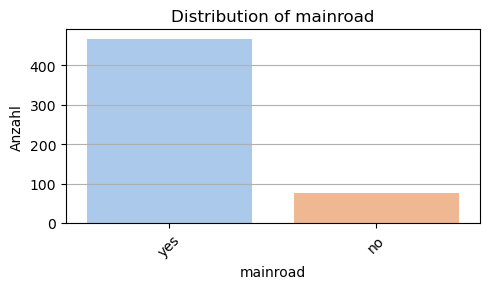

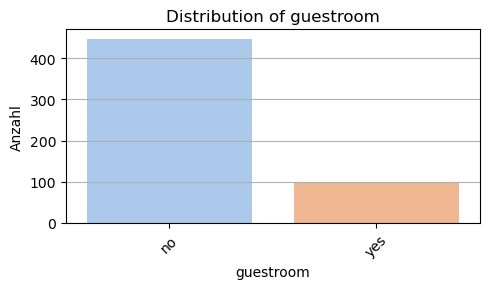

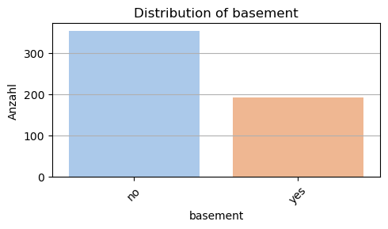

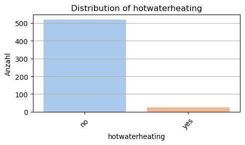

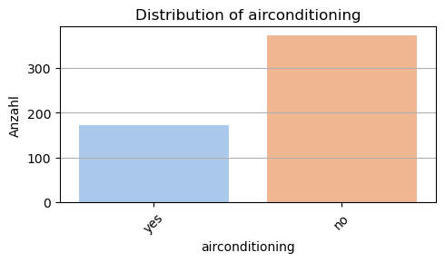

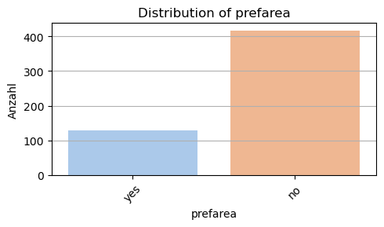

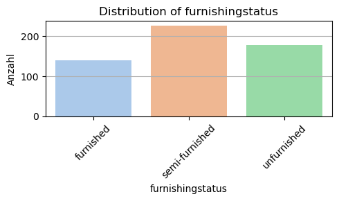

```python
# Analyze categorical data
for column in df.select_dtypes(include=['object']).columns:
    plt.figure(figsize=(5, 3))
    sns.countplot(data=df, x=column, palette='pastel')
    plt.title(f"Distribution of {column}", fontsize=12)
    plt.xlabel(column, fontsize=10)
    plt.ylabel("Anzahl", fontsize=10)
    plt.xticks(rotation=45)
    plt.grid(axis='y')
    plt.tight_layout()
    plt.show()
```

**Häufigkeit von "mainroad"**: Die Mehrheit der Häuser liegt in der Nähe einer Hauptstraße, was möglicherweise den Wert beeinflusst, da solche Lagen oft besser erreichbar sind.

**Furnishingstatus:** Die Verteilung der Möbelzustände zeigt, dass die meisten Häuser semi-möbliert oder unmöbliert sind, was für Käufer von Bedeutung sein kann, die nach bestimmten Wohnstandards suchen.

## Data Engineering

```python
# price / m^2
df['price_per_sqm'] = df['price'] / df['area']
```

```python
# histogram price/m^2
fig1 = px.histogram(df, x='price_per_sqm', nbins=30,
                     title='Verteilung des Preises pro Quadratmeter',
                     labels={'price_per_sqm': 'Preis pro Quadratmeter'},
                     )

fig1.show()
```

[interactive chart not shown]

```python
# number of bathrooms per bedroom
df['bathrooms_per_bedroom'] = df['bathrooms'] / df['bedrooms']
```

```python
# histogram bathrooms per bedroom
fig_histogram = px.histogram(df, x='bathrooms_per_bedroom', nbins=30,
                              title='Verteilung der Badezimmer pro Schlafzimmer',
                              labels={'bathrooms_per_bedroom': 'Badezimmer pro Schlafzimmer'},
                            )

fig_histogram.show()
```

[interactive chart not shown]

```python
# scatter-plot bathroom per bedroom
fig_scatter = px.scatter(df, x='bathrooms_per_bedroom', y='price',
                          title='Preis in Abhängigkeit von Badezimmern pro Schlafzimmer',
                          labels={'bathrooms_per_bedroom': 'Badezimmer pro Schlafzimmer', 'price': 'Preis'},
                          trendline='ols')

fig_scatter.show()
```

[interactive chart not shown]

```python
# amenities
df['amenities_count'] = df[['guestroom', 'basement', 'hotwaterheating', 'airconditioning']].sum(axis=1)
```

```python
# Boxplot for price depending on the number of amenities
fig_boxplot = px.box(df, x='amenities_count', y='price',
                     title='Preisverteilung in Abhängigkeit von der Anzahl der Annehmlichkeiten',
                     labels={'amenities_count': 'Anzahl der Annehmlichkeiten', 'price': 'Preis'})

fig_boxplot.show()
```

[interactive chart not shown]

größte Preisspanne: nononoyes, no 'guestroom', no 'basement', no 'hotwaterheating' and'airconditioning'  
kleinste Preisspanne: yesnoyesno, 'guestroom', no 'basement', 'hotwaterheating' and no 'airconditioning'

**höchster Preis**: Die Gruppe mit den höchsten Preisen ist eine der Gruppen mit vielen „yes“-Werten, etwa „yesyesnoyes“. Der Medianpreis liegt hier über 5M, mit einigen Werten über 10M.

**niedrigster Preis**: Wenig überraschend tendiert die Gruppe mit 'keinen Annehmlichkeiten' zu den niedrigeren Preisen.

# 3) Preprocessing Steps

```python
# drop new-features
df = df.drop(columns=['price_per_sqm', 'bathrooms_per_bedroom', 'amenities_count'])
# Encode Categorical Variables
df = pd.get_dummies(df, columns=['mainroad', 'guestroom', 'basement', 'hotwaterheating',
                                 'airconditioning', 'prefarea', 'furnishingstatus'], drop_first=True)
```

```python
# Normalize Numerical Features
scaler = StandardScaler()
X_scaled = scaler.fit_transform(df.drop(columns=['price']))
y = df['price']
```

```python
# Split Data into Training and Testing Sets
X_train, X_test, y_train, y_test = train_test_split(X_scaled, y, test_size=0.2, random_state=42)
```